# Demonstration of the guided CellRef construction using human lung endothelial data

Minzhe Guo

Compiled: 2022-06-02

In this vignette, we demonstrate the guided CellRef construction pipeline using a subset of our collected human lung scRNA-seq data, which contains 21,971 human lung endothelial cells predicted in three studies (Adams et al., Sci. Adv. 2020, Habermann et al., Sci. Adv. 2020, Travaglini et al., Nature 2020). The runtime of this demo is about 30 minutes.

```r
# source('https://raw.githubusercontent.com/xu-lab/CellRef/main/R/CellRef_functions.R')
library(CellRef)
library(Seurat)
library(monocle3)
library(SingleR)
library(SingleCellExperiment)
library(harmony)
library(RobustRankAggreg)
library(dplyr)
library(reshape2)
library(ggplot2)
library(pheatmap)

options(future.globals.maxSize = 1280000 * 1024^2)

start = Sys.time()
```

Currently, we utilize Seurat (v4) object as main data structure for storage and computation. First, let’s create a Seurat object using the UMI count matrix and cell information of the demo data, which can be downloaded from here: [lung_endo.counts](https://github.com/xu-lab/CellRef/raw/main/data/lung_endo.counts.rds) and [lung_endo.cells](https://github.com/xu-lab/CellRef/raw/main/data/lung_endo.cells.rds).

```r
counts = readRDS(file = "./lung_endo.counts.rds")
cells = readRDS(file = "./lung_endo.cells.rds")

obj <- CreateSeuratObject(counts = counts, project = "lung_endo_demo", meta.data = cells)
obj <- NormalizeData(obj)

print(obj)
```

```
## An object of class Seurat
## 32284 features across 21971 samples within 1 assay
## Active assay: RNA (32284 features, 0 variable features)
```

Download the CellRef [cell type dictionary for lung endothelial cells](https://github.com/xu-lab/CellRef/raw/main/data/Lung_endothelial_ctd.rds) and load the dictionary into R. We assume that the dictionary is a data.frame that contains at least three columns: CellType, Marker, and MarkType (p - positive marker, n - negative marker).

```r
ctd = readRDS(file = "./lung_endothelial_ctd.rds")

print(ctd)
```

```
##    CellType  Marker MarkerType
## 1      CAP1    IL7R          p
## 2      CAP1    FCN3          p
## 3      CAP1 GPIHBP1          p
## 4      CAP2    APLN          p
## 5      CAP2   EDNRB          p
## 6      CAP2    HPGD          p
## 7      CAP2     CA4          p
## 8       AEC    DKK2          p
## 9       AEC    GJA5          p
## 10      AEC     BMX          p
## 11      VEC   ACKR1          p
## 12      VEC   EPHB4          p
## 13      VEC   HDAC9          p
## 14      LEC   PROX1          p
## 15      LEC   MMRN1          p
## 16      LEC   CCL21          p
## 17      LEC   LYVE1          p
## 18     SVEC   ACKR1          p
## 19     SVEC COL15A1          p
## 20     SVEC   ABCB1          p
## 21     SVEC    VWA1          p
```

Step 1: batch correction. By default, we used the mutual nearest matching (MNN, Haghverdi et al., 2018) in Monocle 3 (Cao et al., Nature 2019). Alternative options include: ‘Seurat4-rpca’ - Seurat4’s reciprocal PCA based integration (Hao and Hao et al., 2021) and ‘Harmony’ (Korsunsky et al., Nature Methods 2019).

By setting “do.clustering=T”, we also identified cell clusters after batch correction. By default, the clusters will be stored in a meta.data column named “integrated_clusters”

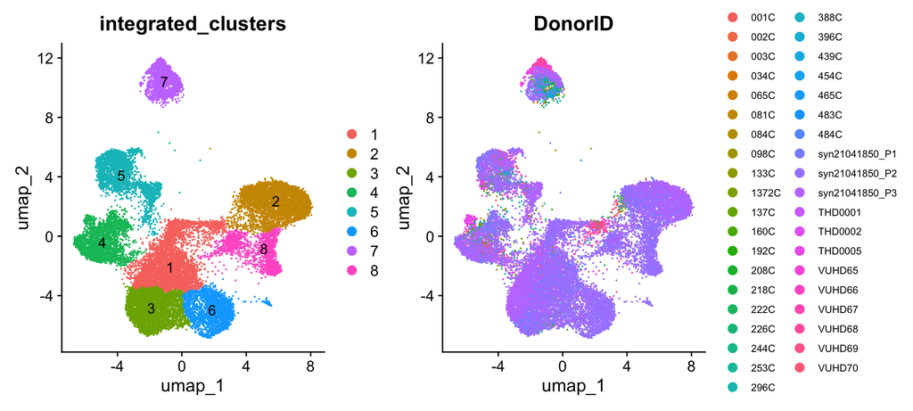

```r
# batch correction of data from different donors
obj = doDataIntegration(obj, integration.batch = "DonorID", method = "Monocle3-mnn", npcs = 200,
    do.clustering = T)

g1 = DimPlot(obj, reduction = "umap", group.by = "integrated_clusters", label = T)
g2 = DimPlot(obj, reduction = "umap", group.by = "DonorID", label = F)
g2 = g2 + theme(legend.text = element_text(size = 8))
g1 + g2
```

Step2: candidate cell clusters. Using the integrated data and cell clusters, we identify the candidate cell clusters for each cell type in the dictionary.

```r
candidate_clusters = findCandidateClusters(obj, ctd, verbose = F)

candidate_clusters
```

| Cluster | CellType |
| --- | --- |
| 4 | AEC |
| 3 | CAP1 |
| 1 | CAP1 |
| 2 | CAP2 |
| 7 | LEC |
| 5 | SVEC |
| 5 | VEC |

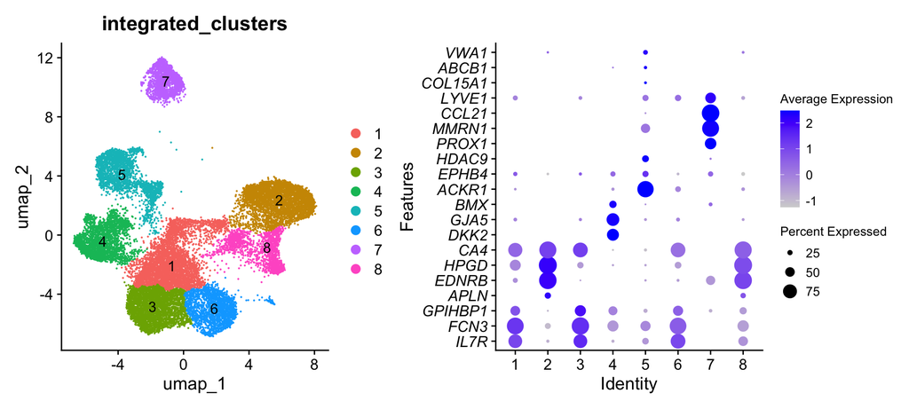

```r
g1 = DimPlot(obj, reduction = "umap", group.by = "integrated_clusters", label = T)

g = DotPlot(obj, assay = "RNA", features = unique(as.character(ctd$Marker)), dot.min = 0.05, group.by = "integrated_clusters")
g = g + coord_flip()
g = g + theme(axis.text.y = element_text(face = "italic"), legend.title = element_text(size = 10),
    legend.text = element_text(size = 10))

g1 + g
```